# A Study of Red Wine Features - Mike Cassell

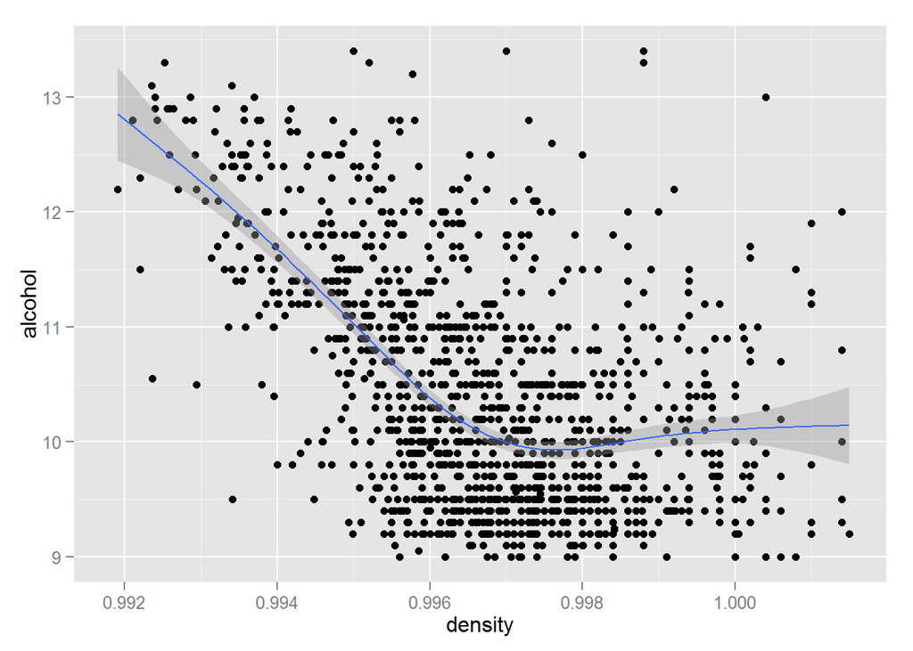

There is a negative correlation between the density and alcohol content up to a point but then it levels out through 0.998 and on-wards.

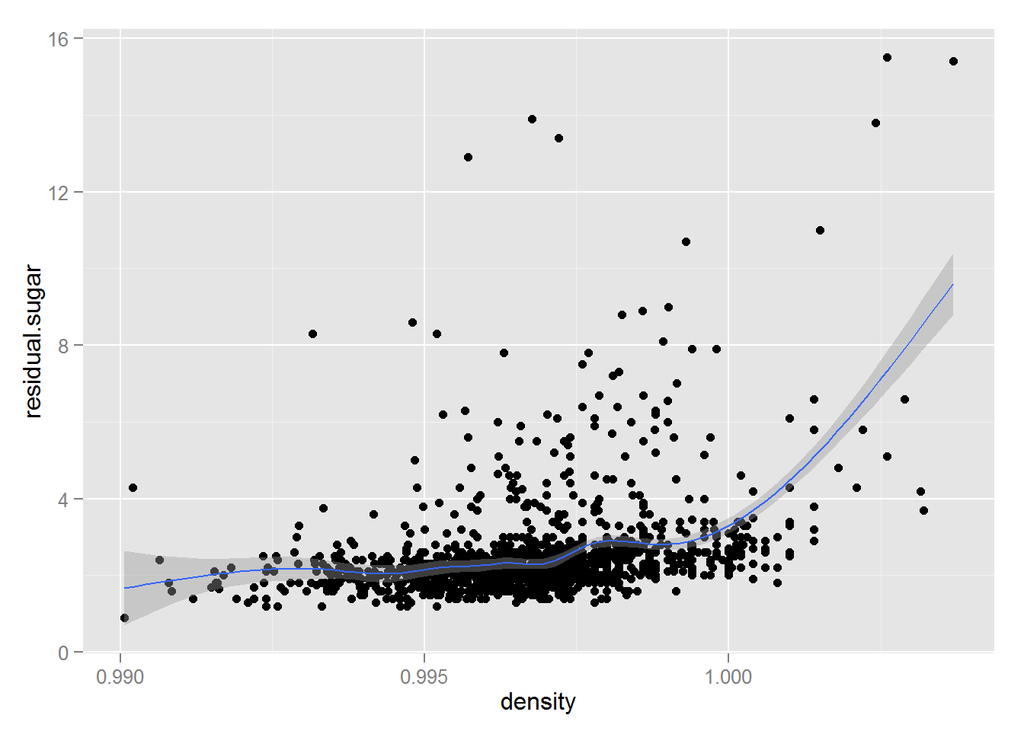

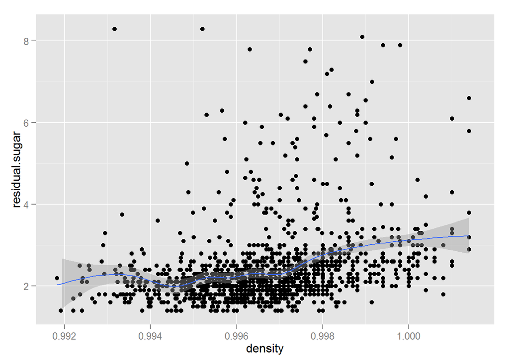

There appears to be a very slightly positive relationship between the residual sugar and the density of the wine.

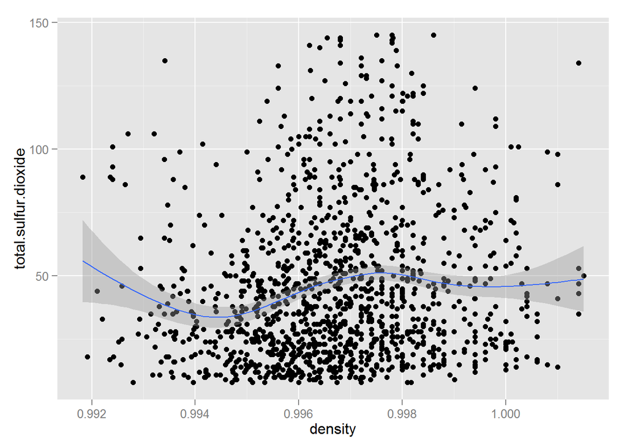

There is no strong relationship between the total sulfur dioxide levels and the density.

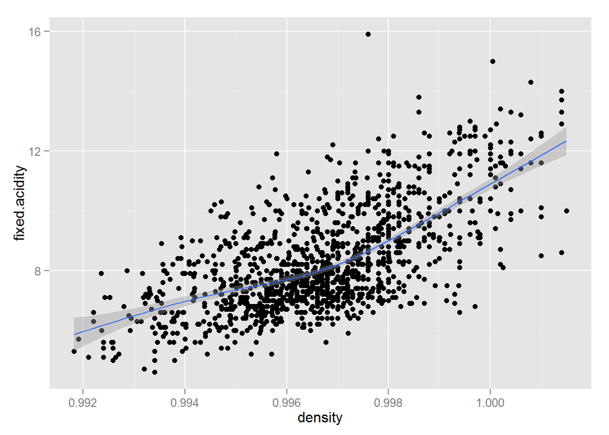

There appears to be a positive relationship between the fixed acidity and density of the wines.

# Bivariate Analysis

### Talk about some of the relationships you observed in this part of the investigation. How did the feature(s) of interest vary with other features in the dataset?

There weren’t any obvious relationships between a single feature and the subjective quality of the wine and while we can see there are ranges that ideal wines fall into for several features, none seem to predict the quality of the wine very strongly on its own.

### Did you observe any interesting relationships between the other features (not the main feature(s) of interest)?

We did find a correlation between density and alcohol, acidity and residual sugar. The density seems to be the most interesting relationship to study as there may be several features that influence the density of the wines.

### What was the strongest relationship you found?

The alcohol level is the biggest predictor in the overall quality of the wine at almost 0.5. The volatile acidity levels are also fairly high (-0.39) and the citric acid and sulfates may play a role at over 0.2 each.

# Multivariate Plots Section

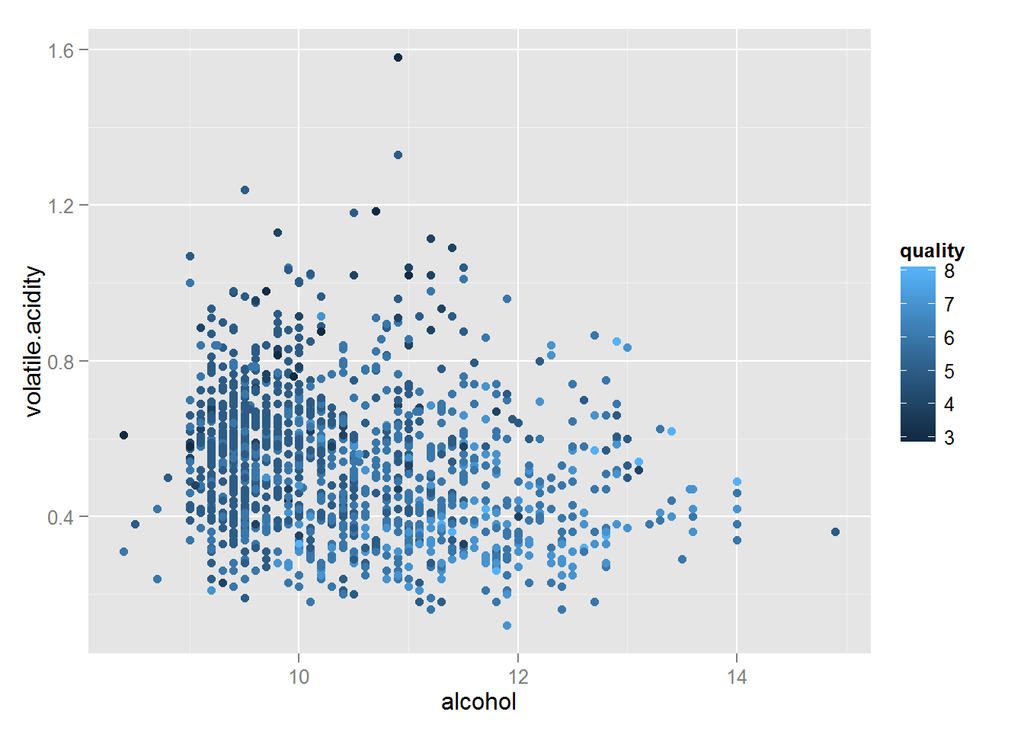

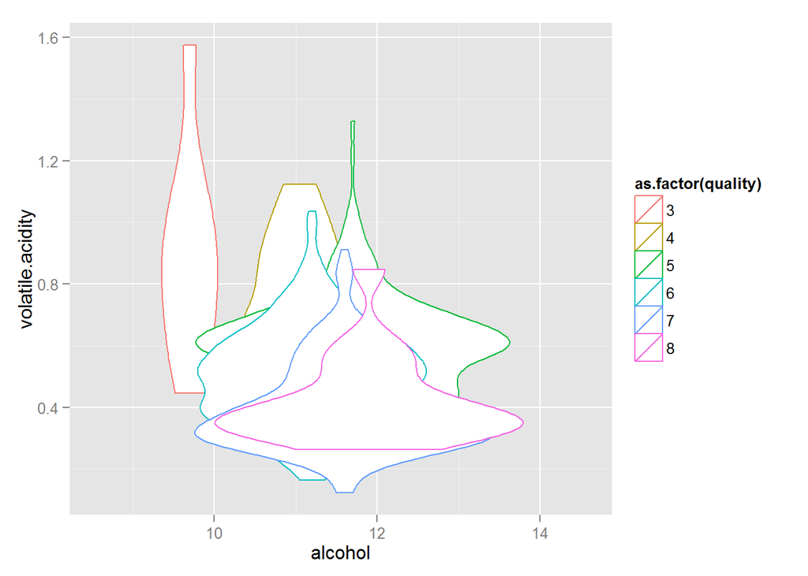

For the same levels of volatility, we can see a higher alcohol content correlates to a higher quality score between 5, 6 and 7 rated wines. Looking at the crowded violin chart, we can see the 8 rated wines tend to have lower volatile acidity and higher alcohol than the other groups. One interesting note with the 7’s vs the 8’s is that they trade off with the 7’s having the lowest volatile acidity of the groups but the 8’s having a slightly higher alcohol concentration.

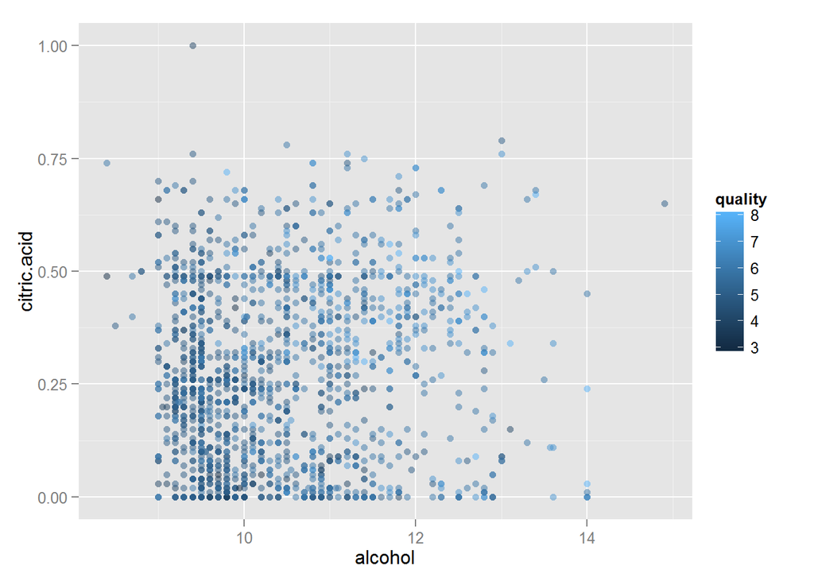

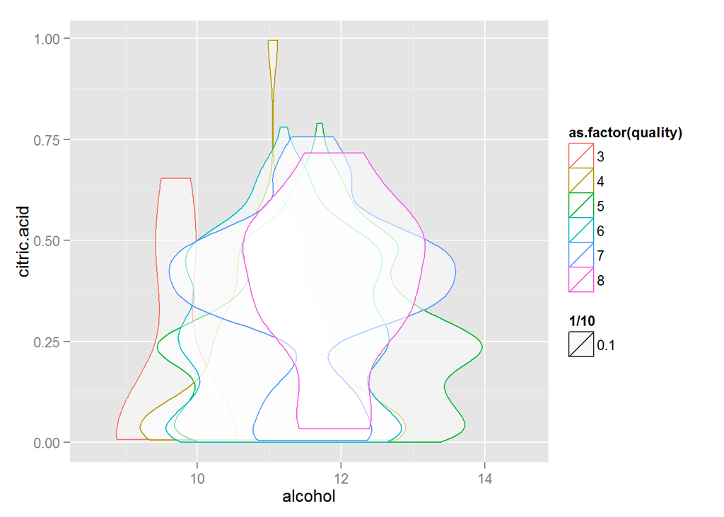

While the 8 rated wines do tend to have higher citric acid scores than the lower scores, there isn’t as clear of a relationship between the lower scores and the citric acid levels.

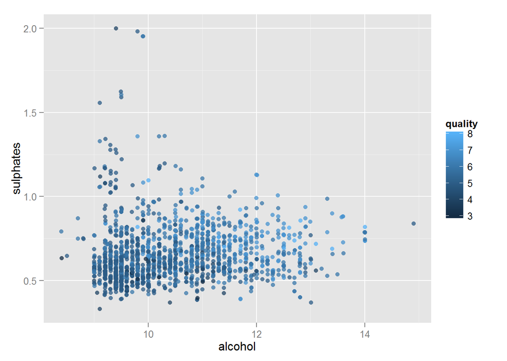

The sulfates seem to have an interesting relationship with the alcohol content. At the lower concentrations (looking below 11% alcohol) there is no real pattern. Above 11% there seems to be some stratification of the quality levels based on sulfates.

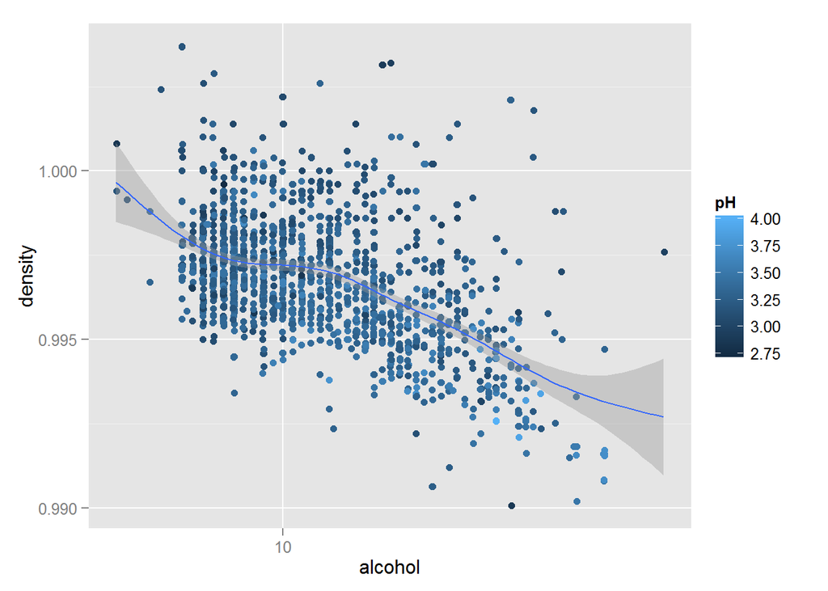

The relationship between pH, density and alcohol appears to exist but is a bit weak.

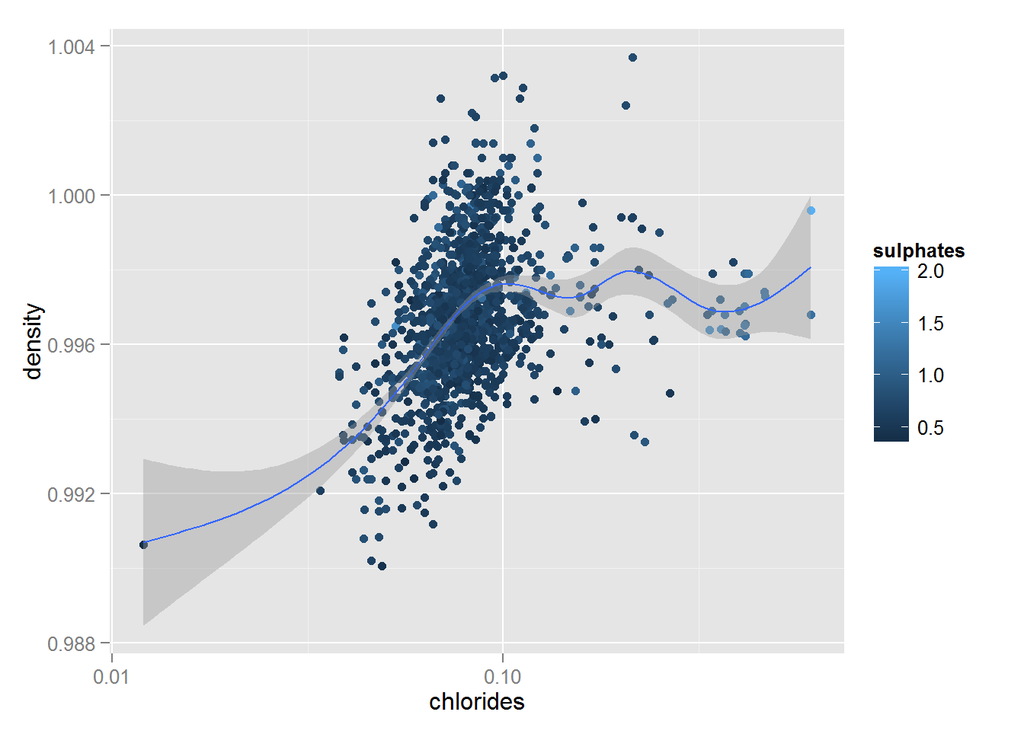

```
##
##  Pearson's product-moment correlation
##
## data:  wines$chlorides and wines$density
## t = 8.1842, df = 1597, p-value = 4.441e-16
## alternative hypothesis: true correlation is not equal to 0
## 95 percent confidence interval:
##  0.1531171 0.2472220
## sample estimates:
##       cor
## 0.2006323
```

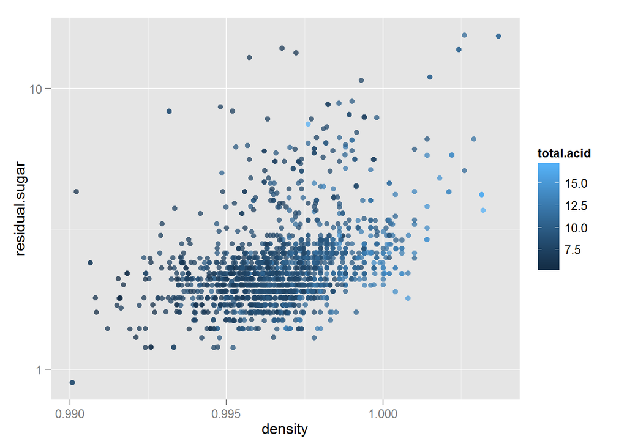

The total acid value seems to strongly relate to the density but not the sugar content.

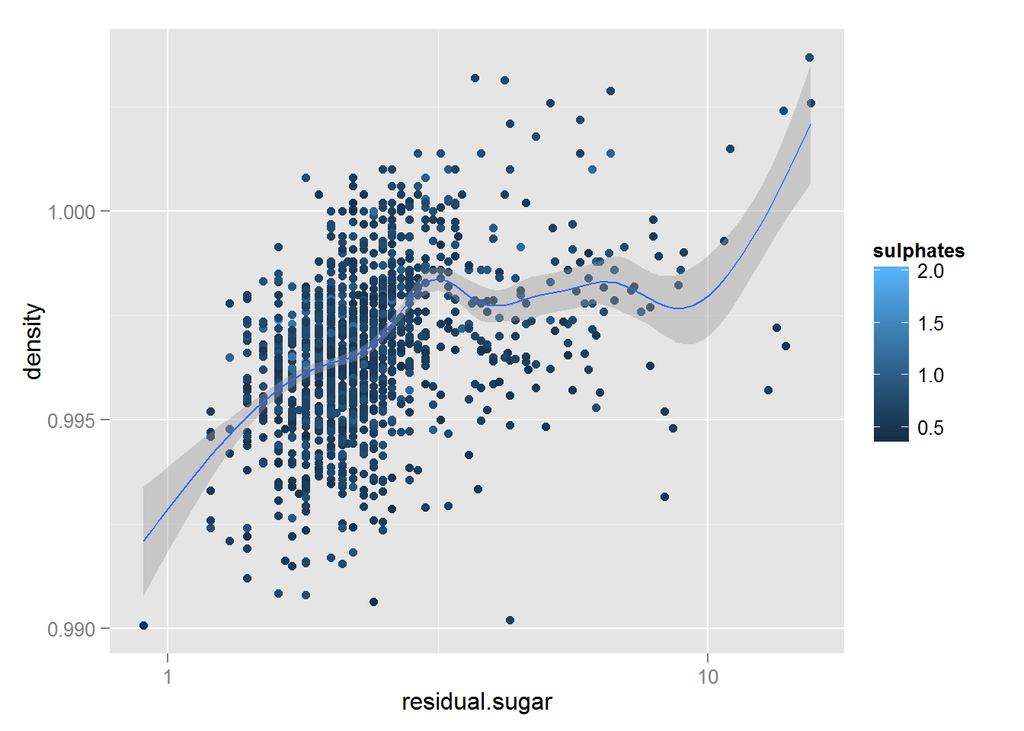

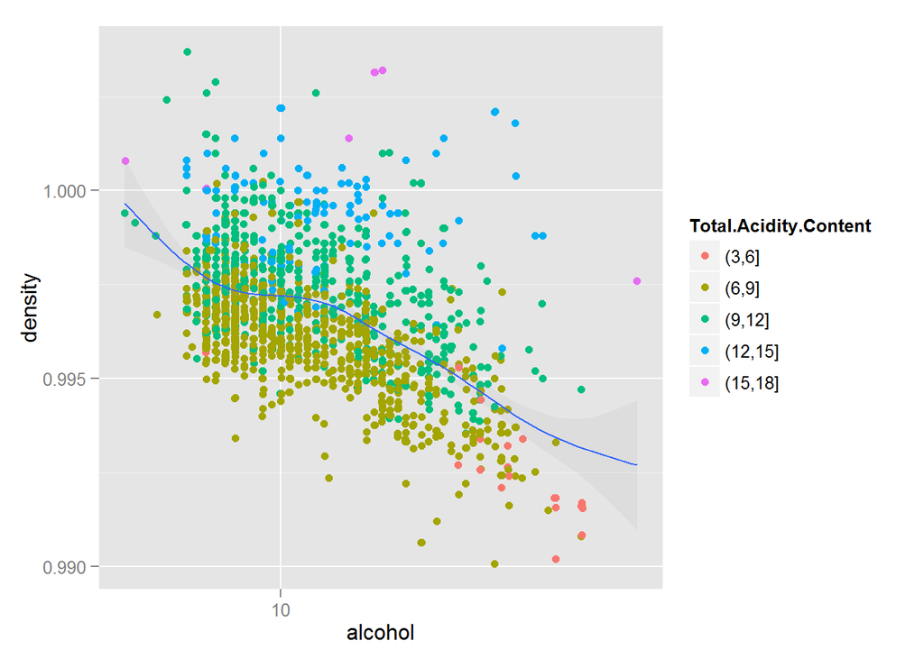

While we haven’t found a great predictor of quality, there does seem to be a very linear relationship between the density and alcohol content when scaled logarithmic. The fixed acidity is also visibly banding at the same alcohol concentrations indicating it may be a somewhat powerful influence over the density independently of the alcohol content.

```r
m1 <- lm(I(density) ~ I(alcohol), data = wines)
m2 <- update(m1, ~ . + Total.Acidity.Content)
m3 <- update(m2, ~ . + residual.sugar)
m4 <- update(m3, ~ . + sulphates)
m5 <- update(m4, ~ . + chlorides)
m6 <- update(m5, ~ . + pH)
mtable(m1, m2, m3, m4, m5, m6)
```

```
##
## Calls:
## m1: lm(formula = I(density) ~ I(alcohol), data = wines)
## m2: lm(formula = I(density) ~ I(alcohol) + Total.Acidity.Content,
##     data = wines)
## m3: lm(formula = I(density) ~ I(alcohol) + Total.Acidity.Content +
##     residual.sugar, data = wines)
## m4: lm(formula = I(density) ~ I(alcohol) + Total.Acidity.Content +
##     residual.sugar + sulphates, data = wines)
## m5: lm(formula = I(density) ~ I(alcohol) + Total.Acidity.Content +
##     residual.sugar + sulphates + chlorides, data = wines)
## m6: lm(formula = I(density) ~ I(alcohol) + Total.Acidity.Content +
##     residual.sugar + sulphates + chlorides + pH, data = wines)
##
## =======================================================================================================
##                                           m1         m2         m3         m4         m5         m6
## -------------------------------------------------------------------------------------------------------
## (Intercept)                            1.006***   1.004***   1.003***   1.002***   1.003***   0.993***
##                                       (0.000)    (0.000)    (0.000)    (0.000)    (0.000)    (0.001)
## I(alcohol)                            -0.001***  -0.001***  -0.001***  -0.001***  -0.001***  -0.001***
##                                       (0.000)    (0.000)    (0.000)    (0.000)    (0.000)    (0.000)
## Total.Acidity.Content: (6,9]/(3,6]                0.001***   0.001***   0.001***   0.001***   0.002***
##                                                  (0.000)    (0.000)    (0.000)    (0.000)    (0.000)
## Total.Acidity.Content: (9,12]/(3,6]               0.003***   0.002***   0.002***   0.002***   0.003***
##                                                  (0.000)    (0.000)    (0.000)    (0.000)    (0.000)
## Total.Acidity.Content: (12,15]/(3,6]              0.005***   0.004***   0.004***   0.004***   0.006***
##                                                  (0.000)    (0.000)    (0.000)    (0.000)    (0.000)
## Total.Acidity.Content: (15,18]/(3,6]              0.007***   0.006***   0.006***   0.006***   0.008***
##                                                  (0.000)    (0.000)    (0.000)    (0.000)    (0.000)
## residual.sugar                                               0.000***   0.000***   0.000***   0.000***
##                                                             (0.000)    (0.000)    (0.000)    (0.000)
## sulphates                                                               0.001***   0.001***   0.001***
##                                                                        (0.000)    (0.000)    (0.000)
## chlorides                                                                         -0.000      0.001
##                                                                                   (0.001)    (0.001)
## pH                                                                                            0.003***
##                                                                                              (0.000)
## -------------------------------------------------------------------------------------------------------
## R-squared                                  0.246      0.595      0.694      0.704      0.704      0.732
## adj. R-squared                             0.246      0.594      0.693      0.702      0.702      0.730
## sigma                                      0.002      0.001      0.001      0.001      0.001      0.001
## F                                        521.583    467.743    601.306    539.669    472.061    481.844
## p                                          0.000      0.000      0.000      0.000      0.000      0.000
## Log-likelihood                          7987.444   8483.803   8707.806   8733.856   8734.033   8813.772
## Deviance                                   0.004      0.002      0.002      0.002      0.002      0.002
## AIC                                   -15968.888 -16953.606 -17399.611 -17449.713 -17448.065 -17605.543
## BIC                                   -15952.757 -16915.966 -17356.594 -17401.318 -17394.294 -17546.395
## N                                       1599       1599       1599       1599       1599       1599
## =======================================================================================================
```

# Multivariate Analysis

### Talk about some of the relationships you observed in this part of the investigation. Were there features that strengthened each other in terms of looking at your feature(s) of interest?

The relationship between the various features and density became more apparent. The pH, citric acid content, the sulfate content and the residual sugar amongst others appear to be strongly related which intuitively makes sense - adding compounds of differing densities will have an effect on the overall density of the fluid. We can say that alcohol lowers the density while the acidity increases it.

### Were there any interesting or surprising interactions between features?

The fixed and citric acid levels are both positively correlated with the density of the wine but the volatile acidity is negatively correlated. This seems very surprising as the pH is also correlated with the density so it would be expected that any acidic compound should raise the density.

### OPTIONAL: Did you create any models with your dataset? Discuss the strengths and limitations of your model.

# Final Plots and Summary

### Plot One

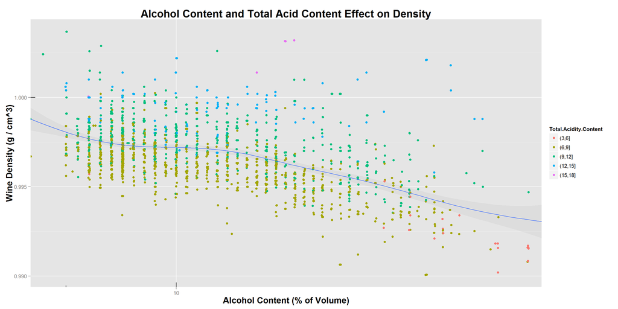

### Description One

This plot shows the relationship between the alcohol content, density of the wine and the total acid content of the components of the wine. It illustrates that the alcohol and density have a negative relationship while the acid content has a positive relationship that seems to explain most of the error range observed with the alcohol content alone.

### Plot Two

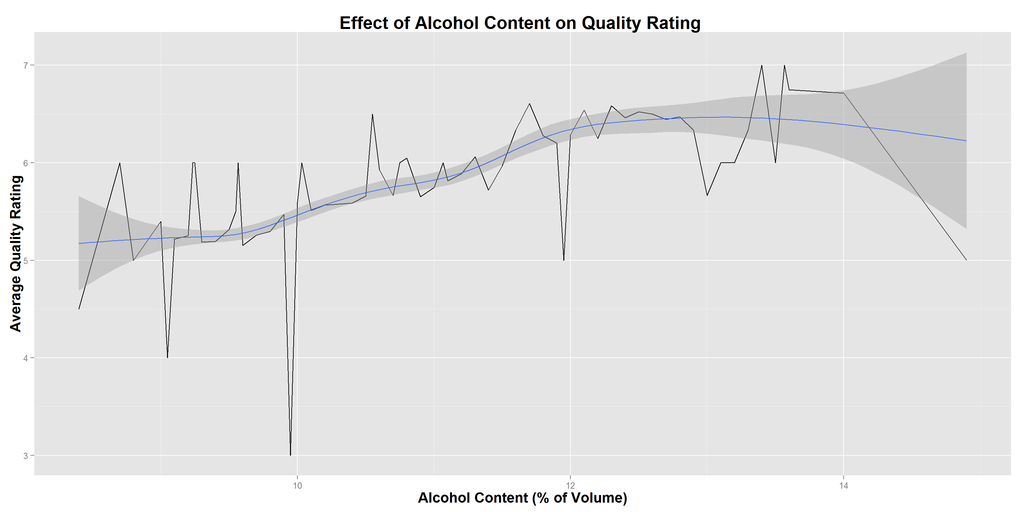

### Description Two

This plot outlines the positive relationship between the alcohol content and subjective quality rating of the wines. This was the strongest relationship observed and it’s evident that there must be other moderating factors on the subjective quality of wines.

### Plot Three

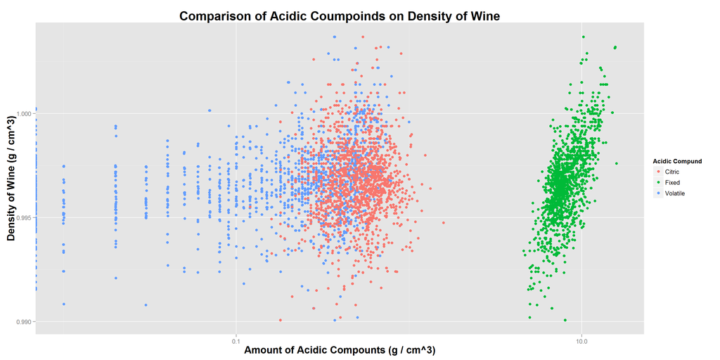

### Description Three

This plot was created to examine why the relationship between citric acid and density was so weak compared to the volatile and fixed acids. Due to the differences in quantity, a log 10 scale is used to show the range on contents in an appropriate manner. The fixed acids show a fairly clear linear relationship while the volatile is a but less clear. The citric acid doesn’t appear to have any relation to density which is strange since there is actually more citric acid in the majority of wines than there is volatile which shows at least some correlation numerically.

# Reflection

This was a really informative if frustrating exercise. I was frustrated as there really doesn’t seem to be any accurate way of predicting the quality of wines (my primary goal) from the information present. While a number of the factors did show some linear correlations, more of the features seemed to have bands that above or below, the quality rating would fall. Potentially more could have been done by using more advanced analysis or statistical techniques (possibly using exponential instead of linear models.)

The analysis I found worked best for me was to carefully iterate through the features individually and then begin making comparisons in the second section. Moving onto the third, I tried to associate some of the previously discovered correlations to others to find mediating relationships.

It was very rewarding as I was able to uncover a set of relationships between some of the compounds present in wines and their effect on the density of the wine. This seems like a strong predictive relationship that could be further improved with additional analysis and exploration of the underlying chemical data. The fact that the volatile acidity didn’t have much of an effect on the density while the others did.

# References

Plotting correlation matrix as colored ellipses: http://www.cookbook-r.com/Graphs/Correlation_matrix/

Graphing Hints: http://www.cookbook-r.com/Graphs/

Setting Plot Width in RMD Files: http://stackoverflow.com/questions/13540955/ggplot2-r-markdown